# IE 582 Project - FALL'24

## Group 5

##### Berat Kubilay Güngez - 2021402087

##### Sude Yılmaz - 2024702057

1. Introduction
2. Related literature
3. Approach
   - 3a. Data Preprocessing
   - 3b. Decision Trees
   - 3c. Random Forest Classification
   - 3d. Gradient Boosted Decision Trees
4. Results
5. Conclusions and Future Work
6. Code
7. References

## Introduction

**1.1 Problem Description**

The problem involves developing a live betting strategy for soccer matches, where the task is to predict the match outcome as home win, draw, or away win at an optimal moment during the game. This must be done using real-time data and without the ability to revise the prediction after the decision point. These conditions simulates real-world betting scenerios which allows to draw insights from the results more realistically.

**1.2 Proposed Approaches**

The approach revolves around the real-time analysis of in-game odds. Various models are developed to predict match outcomes based on the information available at each point during the match. The models include decision trees, random forests, and gradient-boosted decision trees. Each model is trained and validated using different datasets, with cross-validation applied with many different parameter sets to determine the best model based on accuracy performance metrics. Using the predictive analysis from these models, a betting strategy is developed that places a bet if certain conditions are met at a specific point in the game. Additionally, the model's performance was evaluated in terms of both accuracy and profitability. This demonstrates a balanced approach to manage risk and reward in live betting scenarios.

**1.3 Descriptive Analysis of the Given Data**

Overall, the dataset offers a comprehensive view of match dynamics, from basic temporal data to detailed performance statistics, enabling deep insights into team performance, match progress, and outcomes.

## Related literature

**(Štrumbelj 2014)** provides an interpretation and adjustment of betting odds that brings a framework for understanding how probabilities can be derived from bookmakers' odds. In the context of sports betting, odds are often presented with a margin, which ensures profitability for bookmakers. This margin ensures that the sum of implied probabilities exceed 1. Therefore, this creates the need for normalization to extract true probabilities from the odds. Štrumbelj proposes a normalization technique that adjusts the odds to remove the bookmaker's margin. This technique involves dividing each implied probability by the sum of all implied probabilities. By applying this normalization, bettors can more accurately assess the value of different bets, which can lead to identify opportunities where the market odds are misaligned with the actual probabilities. This normalization technique has been utilized within this project in various betting models to improve their predictive accuracy.

**(Wong, Li, Le, Bhangu, & Bhatia, 2025)** offers a comprehensive exploration of various machine learning (ML) techniques applied to predict outcomes in the English Premier League (EPL). The study highlights the growing interest in using ML models for sports predictions. Decision trees are applied due to their simplicity and interpretability, the decision tree model serves as a baseline in many predictive analytics frameworks. The study uses it to compare against more complex models like Random Forest and Gradient Boosted Decision Trees. The study finds random forest to be a powerful ensemble method that improves prediction accuracy by averaging the results of multiple decision trees, reducing the risk of overfitting. Gradient boosting framework is employed for its efficiency and effectiveness in handling large datasets and capturing intricate patterns within the data. The study demonstrates that it often outperforms simpler models in terms of prediction accuracy. The study benchmarks its model predictions against those of major bookmakers, providing insights into the potential of machine learning models to outperform traditional betting odds. This comparison can guide the development of betting strategies that develop model predictions to identify bets.

To enhance the learning accuracy and efficiency of the gradient boosted decision tree model, **(Sun 2020)** proposes an advanced parameter optimization strategy. In the study Sun introduces a dual approach for XGBoost parameter tuning. The strategy employs grid search combined with k-fold cross-validation to systematically explore parameter spaces and identify optimal settings. Furthermore, Sun integrates a Bayesian Optimization approach that significantly reduces the training time while enhancing the classification accuracy compared to traditional grid search methods. In simulation experiments, Sun demonstrates that the Bayesian Optimization-based XGBoost model surpasses the grid search method in both training accuracy and efficiency.

Overall, all these studies and their respective implementations brought several insights to this project to develop both the machine learning techniques, generate the betting strategy, and improve the predictive power of the models.

## Approach

Our approach consists of:

**1) Data Preprocessing:**

- Analyzing the data
- Handling missing data
- Defining new columns and deriving new information from the current data that could bring more insights to the results
- Removing instances that create noise in the data
- Splitting data to train, validation and test sets
- Defining unrelated columns to the outcome

**2) Model Fitting:**

- Fitting decision tree, random forest and gradient boosted decision tree models using Cross Validation
- Developing a betting strategy

**3)Performance Evaluation:**

- Evaluating performance based on accuracy of the models
- Evaluating performance based on the profitability of the betting strategies

### Data Preprocessing

```python
import pandas as pd # data processing, CSV file
import datetime # to split the data into train and test
import matplotlib.pyplot as plt # for plotting
import seaborn as sns # for plotting
import numpy as np # for mathematical operations
import warnings # to reduce warnings if needed
from sklearn.tree import DecisionTreeClassifier # for building decision tree model
from sklearn.ensemble import RandomForestClassifier # for building random forest model
from xgboost import XGBClassifier # for building XGBoost model
from sklearn.model_selection import GridSearchCV # for parameter tuning
from sklearn.metrics import accuracy_score, confusion_matrix # for model evaluation
from sklearn.model_selection import train_test_split # for splitting the data into two sets; validation and training
import random
random.seed(2512)
np.random.seed(2512)
```

```python
data_loc = "match_data"

df = pd.read_csv(data_loc)

mask = (df[["suspended","stopped"]] == False).all(axis=1) # mask for rows where all columns are False
df = df[mask] # remove rows where all columns are False
df = df.drop(["suspended","stopped"], axis=1) # remove the columns

df.head(5)
```

|  | fixture_id | halftime | current_time | half_start_datetime | match_start_datetime | minute | second | latest_bookmaker_update | 1 | 2 | ... | Throwins - home | Total Crosses - away | Total Crosses - home | Yellowcards - away | Yellowcards - home | Yellowred Cards - away | Yellowred Cards - home | current_state | final_score | result |
| --- | --- | --- | --- | --- | --- | --- | --- | --- | --- | --- | --- | --- | --- | --- | --- | --- | --- | --- | --- | --- | --- |
| 0 | 19172016.0 | 1st-half | 2024-08-09 18:11:36 | 2024-08-09 18:01:37 | 2024-08-09 18:01:37 | 9 | 59 | 2024-08-09 18:11:28 | 1.22 | 10.0 | ... | 1.0 | 0.0 | 3.0 | 0.0 | 0.0 | 0.0 | 0.0 | X | 2-1 | 1 |
| 1 | 19172016.0 | 1st-half | 2024-08-09 18:27:30 | 2024-08-09 18:01:37 | 2024-08-09 18:01:37 | 25 | 53 | 2024-08-09 18:27:24 | 1.20 | 13.0 | ... | 11.0 | 1.0 | 12.0 | 0.0 | 0.0 | 0.0 | 0.0 | X | 2-1 | 1 |
| 2 | 19172016.0 | 1st-half | 2024-08-09 18:28:25 | 2024-08-09 18:01:37 | 2024-08-09 18:01:37 | 26 | 48 | 2024-08-09 18:28:20 | 1.20 | 13.0 | ... | 11.0 | 1.0 | 13.0 | 0.0 | 0.0 | 0.0 | 0.0 | X | 2-1 | 1 |
| 3 | 19172016.0 | 1st-half | 2024-08-09 18:29:32 | 2024-08-09 18:01:37 | 2024-08-09 18:01:37 | 27 | 55 | 2024-08-09 18:29:28 | 1.20 | 13.0 | ... | 11.0 | 1.0 | 13.0 | 0.0 | 0.0 | 0.0 | 0.0 | X | 2-1 | 1 |
| 8 | 19172016.0 | 1st-half | 2024-08-09 18:34:18 | 2024-08-09 18:01:37 | 2024-08-09 18:01:37 | 32 | 41 | 2024-08-09 18:34:12 | 1.20 | 15.0 | ... | 11.0 | 1.0 | 14.0 | 0.0 | 0.0 | 0.0 | 0.0 | X | 2-1 | 1 |

5 rows × 104 columns

```python
result_counts = df['result'].value_counts() # count the number of each result

result_counts
```

```
result
1    24148
2    16588
X    15391
Name: count, dtype: int64
```

### Handling Missing Values:

- **Numerical columns**: Missing values are replaced with the mean of their respective group, ensuring that the imputation respects the grouping structure.
- **Categorical column (`'current_state'`)**: Missing values are forward filled within the same group, maintaining categorical consistency.
- Instances that the `current_state` column could not be filled with forward filling due to having missing data for fixture_id at that instance are dropped.

```python
for col in df.isna():
    if df[col].isna().sum() > 0:
        print("{col} has {n} missing values".format(col=col, n=df[col].isna().sum())) # print the number of missing values in each column

# impute missing values with the mean of the column
for column in df.columns:
    if column != 'current_state' and df[column].isnull().sum() > 0: # if the column is not current_state since it is categorical
        df[column] = df.groupby('fixture_id', observed=True)[column].transform(lambda x: x.fillna(x.mean()))

# forward fill the current_state column, since it is categorical
df['current_state'] = df.groupby('fixture_id')['current_state'].ffill()
```

```
Accurate Crosses - away has 2900 missing values
Accurate Crosses - home has 2879 missing values
Assists - away has 26239 missing values
Assists - home has 26237 missing values
Attacks - away has 38 missing values
Attacks - home has 32 missing values
Ball Possession % - away has 23 missing values
Ball Possession % - home has 22 missing values
Ball Safe - away has 21456 missing values
Ball Safe - home has 21452 missing values
Challenges - away has 4492 missing values
Challenges - home has 4485 missing values
Corners - away has 73 missing values
Corners - home has 65 missing values
Counter Attacks - away has 36836 missing values
Counter Attacks - home has 36834 missing values
Dangerous Attacks - away has 51 missing values
Dangerous Attacks - home has 45 missing values
Dribble Attempts - away has 7466 missing values
Dribble Attempts - home has 7441 missing values
Fouls - away has 1566 missing values
Fouls - home has 1555 missing values
Free Kicks - away has 51075 missing values
Free Kicks - home has 51075 missing values
Goal Attempts - away has 25309 missing values
Goal Attempts - home has 25302 missing values
Goal Kicks - away has 4376 missing values
Goal Kicks - home has 4369 missing values
Goals - away has 38 missing values
Goals - home has 36 missing values
Headers - away has 9678 missing values
Headers - home has 9672 missing values
Hit Woodwork - away has 194 missing values
Hit Woodwork - home has 173 missing values
Injuries - away has 41602 missing values
Injuries - home has 41600 missing values
Interceptions - away has 4077 missing values
Interceptions - home has 4056 missing values
Key Passes - away has 5248 missing values
Key Passes - home has 5244 missing values
```

[output cut: 30 more lines]

```
Successful Passes - away has 386 missing values
Successful Passes - home has 383 missing values
Successful Passes Percentage - away has 152 missing values
Successful Passes Percentage - home has 150 missing values
Tackles - away has 1869 missing values
Tackles - home has 1858 missing values
Throwins - away has 1082 missing values
Throwins - home has 1075 missing values
Total Crosses - away has 2127 missing values
Total Crosses - home has 2116 missing values
Yellowcards - away has 78 missing values
Yellowcards - home has 67 missing values
Yellowred Cards - away has 21284 missing values
Yellowred Cards - home has 21277 missing values
current_state has 38 missing values
```

```python
for col in df.isna():
    if df[col].isna().sum() > 0:
        print("{col} has {n} missing values".format(col=col, n=df[col].isna().sum())) # print the number of missing values in each column
```

```
Assists - away has 8909 missing values
Assists - home has 8909 missing values
Ball Safe - away has 7211 missing values
Ball Safe - home has 7211 missing values
Counter Attacks - away has 28066 missing values
Counter Attacks - home has 28066 missing values
Dribble Attempts - away has 30 missing values
Dribble Attempts - home has 30 missing values
Fouls - away has 6 missing values
Fouls - home has 6 missing values
Free Kicks - away has 51070 missing values
Free Kicks - home has 51070 missing values
Goal Attempts - away has 8229 missing values
Goal Attempts - home has 8229 missing values
Goal Kicks - away has 560 missing values
Goal Kicks - home has 560 missing values
Headers - away has 4262 missing values
Headers - home has 4262 missing values
Injuries - away has 25464 missing values
Injuries - home has 25464 missing values
Key Passes - away has 6 missing values
Key Passes - home has 6 missing values
Long Passes - away has 2010 missing values
Long Passes - home has 2010 missing values
Offsides - away has 2823 missing values
Offsides - home has 2823 missing values
Saves - away has 198 missing values
Saves - home has 198 missing values
Successful Dribbles - away has 6 missing values
Successful Dribbles - home has 6 missing values
Successful Headers - away has 4262 missing values
Successful Headers - home has 4262 missing values
Yellowred Cards - away has 7128 missing values
Yellowred Cards - home has 7128 missing values
current_state has 38 missing values
```

```python
df = df.dropna(subset=["current_state"]) # drop rows where current_state is missing

df["current_state"] = [1 if x == "1" else 2 if x == "2" else 0 for x in df["current_state"]] # convert the current_state column to 1, 2, 0
```

### Defining New Columns:

The below columns added to the data frame by combining information from the current data frame.

- **Total Goals**: Sum of home and away goals.
- **Total Red Cards**: Sum of red cards for both home and away teams.
- **Total Yellow Cards**: Sum of yellow cards for both teams.
- **Total Injuries**: Sum of injuries for both teams.
- **Total Substitutions**: Sum of substitutions for both teams.
- **Goal Difference**: Difference between home and away goals.
- **Dangerous Attacks Difference**: Difference between home and away dangerous attacks.
- **Ball Possession % Difference**: Difference in ball possession percentage between home and away teams.
- **Goal Attempts Difference**: Difference in goal attempts between home and away teams.
- **Successful Passes % Difference**: Difference in successful passes percentage between home and away teams.
- **Prob Columns**: Each column of odds converted into probabilities, which represent the likelihood of each outcome (home win, away win, draw) based on the odds. Later these probabilities are normalized by dividing each probability by the sum of probabilities across each row. This ensures that the total probability for each match sums to 1. (Štrumbelj 2014)

This process enriches the original DataFrame with new analytical features and predicted probabilities for betting strategies. (Wong, Li, Le, Bhangu, & Bhatia, 2025)

```python
# Create new columns as a batch
new_columns = pd.DataFrame({
    "Total Goals": df["Goals - home"] + df["Goals - away"],
    "Total Red Cards": df["Redcards - home"] + df["Redcards - away"],
    "Total Yellow Cards": df["Yellowcards - home"] + df["Yellowcards - away"],
    "Total Injuries": df["Injuries - home"] + df["Injuries - away"],
    "Total Substitutions": df["Substitutions - home"] + df["Substitutions - away"],
    "Goal Difference": df["Goals - home"] - df["Goals - away"],
    "Dangerous Attacks Difference": df["Dangerous Attacks - home"] - df["Dangerous Attacks - away"],
    "Ball Possession % Difference": df["Ball Possession % - home"] - df["Ball Possession % - away"],
    "Goal Attempts Difference": df["Goal Attempts - home"] - df["Goal Attempts - away"],
    "Successful Passes % Difference": df["Successful Passes Percentage - home"] - df["Successful Passes Percentage - away"]
})

# Concatenate the new columns with the original DataFrame
df = pd.concat([df, new_columns], axis=1)

# Add probabilities of home win, away win and draw
df_odds = df.copy()
df_odds = df_odds.loc[:, "1":"X"]
prob_df = 1 / df_odds
prob_df.columns = ["Pr{Home Win}", "Pr{Away Win}", "Pr{Draw}"]
normalized_prob_df = prob_df.div(prob_df.sum(axis=1), axis=0)
df = pd.concat([df, normalized_prob_df], axis=1)
```

### Removing Instances that Create Noise:

Certain events that might introduce noise or unexpected variability in the match outcomes are determined. These events are likely to distort the prediction models or betting strategies.

- **Goals in the first 10 minutes**: Identifies matches where a goal is scored within the first 10 minutes of the first half.
- **Goals after 80 minutes**: Looks for matches where a goal is scored after the 80th minute but before the 40th minute of the second half to avoid including final moments.
- **Red cards in the first 15 minutes**: Flags matches with a red card issued within the first 15 minutes of the first half.
- **Red cards after 75 minutes**: Identifies matches with a red card issued after the 75th minute but before the 35th minute of the second half.
- **Yellow cards in the first 10 minutes**: Marks matches with a yellow card within the first 10 minutes of the first half.
- **Injuries in the first 15 minutes**: Detects matches where an injury occurs within the first 15 minutes of the first half.
- **Substitutions in the first 30 minutes**: Finds matches with substitutions within the first 30 minutes of the first half.

By removing these rows, the dataset is cleansed of these potentially distorting influences, aiming to make the remaining data more suitable for accurate modeling and prediction without anomalies. This leads to a more reliable analysis by focusing on matches that are less likely to be biased by unusual or extreme events.

```python
# Goal in first 10 mins
df["Goal_in_first_10_mins"] = (df["halftime"] == "1st-half") & (df["minute"] < 10) & (df["Total Goals"] >= 1)

# Prepare matches dataframe for "Goal_after_80_mins"
matches = df[(df["minute"] < 40) & (df["halftime"] == "2nd-half")]
matches = matches.loc[matches.groupby("fixture_id")["Total Goals"].idxmax()]
matches = matches[["fixture_id", "Total Goals"]]

# Goal after 80 mins
df = df.merge(matches, on="fixture_id", how="left", suffixes=("", "_max"))
df["Goal_after_80_mins"] = (df["minute"] >= 40) & (df["halftime"] == "2nd-half") & (df["Total Goals"] > df["Total Goals_max"])
df.drop(columns=["Total Goals_max"], inplace=True)

# Red card in first 15 mins
df["Redcard_in_first_15_mins"] = (df["halftime"] == "1st-half") & (df["minute"] < 15) & (df["Total Red Cards"] >= 1)

# Prepare matches dataframe for "Red_cards_after_75_mins"
matches = df[(df["minute"] < 35) & (df["halftime"] == "2nd-half")]
matches = matches.loc[matches.groupby("fixture_id")["Total Red Cards"].idxmax()]
matches = matches[["fixture_id", "Total Red Cards"]]

# Red cards after 75 mins
df = df.merge(matches, on="fixture_id", how="left", suffixes=("", "_max"))
df["Red_cards_after_75_mins"] = (df["minute"] >= 35) & (df["halftime"] == "2nd-half") & (df["Total Red Cards"] > df["Total Red Cards_max"])
df.drop(columns=["Total Red Cards_max"], inplace=True)

# Yellow card in first 10 mins
df["Yellowcard_in_first_10_mins"] = (df["halftime"] == "1st-half") & (df["minute"] < 10) & (df["Total Yellow Cards"] >= 1)

# Injuries in first 15 mins
df["Injuries_in_first_15_mins"] = (df["halftime"] == "1st-half") & (df["minute"] < 15) & (df["Total Injuries"] >= 1)

# Substitutions in first 30 mins
df["Substutions_in_first_30_mins"] = (df["halftime"] == "1st-half") & (df["minute"] < 30) & (df["Total Substitutions"] >= 1)

# List of columns to check
columns_to_check = [
    "Goal_in_first_10_mins",
    "Redcard_in_first_15_mins",
    "Yellowcard_in_first_10_mins",
    "Injuries_in_first_15_mins",
    "Goal_after_80_mins",
    "Substutions_in_first_30_mins",
    "Red_cards_after_75_mins"
]

# Print event counts
for col in columns_to_check:
    print(f"Number of {col} events: {df[col].sum()}")
print("\n")
print(f"Current number of rows: {len(df)}")

# Remove rows with any of the specified events
df = df[~df[columns_to_check].any(axis=1)]
df = df.drop(columns=columns_to_check)

# Print updated row count
print(f"Number of rows after removing matches with events: {len(df)}")
```

```
Number of Goal_in_first_10_mins events: 512
Number of Redcard_in_first_15_mins events: 11
Number of Yellowcard_in_first_10_mins events: 225
Number of Injuries_in_first_15_mins events: 4592
Number of Goal_after_80_mins events: 576
Number of Substutions_in_first_30_mins events: 824
Number of Red_cards_after_75_mins events: 260


Current number of rows: 56089
Number of rows after removing matches with events: 49653
```

```python
df.head(5)
```

|  | fixture_id | halftime | current_time | half_start_datetime | match_start_datetime | minute | second | latest_bookmaker_update | 1 | 2 | ... | Total Injuries | Total Substitutions | Goal Difference | Dangerous Attacks Difference | Ball Possession % Difference | Goal Attempts Difference | Successful Passes % Difference | Pr{Home Win} | Pr{Away Win} | Pr{Draw} |
| --- | --- | --- | --- | --- | --- | --- | --- | --- | --- | --- | --- | --- | --- | --- | --- | --- | --- | --- | --- | --- | --- |
| 1 | 19172016.0 | 1st-half | 2024-08-09 18:27:30 | 2024-08-09 18:01:37 | 2024-08-09 18:01:37 | 25 | 53 | 2024-08-09 18:27:24 | 1.20 | 13.0 | ... | 2.0 | 0.0 | 0.0 | 24.0 | 52.0 | 4.176471 | 35.0 | 0.773810 | 0.071429 | 0.154762 |
| 2 | 19172016.0 | 1st-half | 2024-08-09 18:28:25 | 2024-08-09 18:01:37 | 2024-08-09 18:01:37 | 26 | 48 | 2024-08-09 18:28:20 | 1.20 | 13.0 | ... | 2.0 | 0.0 | 0.0 | 24.0 | 58.0 | 4.176471 | 38.0 | 0.773810 | 0.071429 | 0.154762 |
| 3 | 19172016.0 | 1st-half | 2024-08-09 18:29:32 | 2024-08-09 18:01:37 | 2024-08-09 18:01:37 | 27 | 55 | 2024-08-09 18:29:28 | 1.20 | 13.0 | ... | 2.0 | 0.0 | 0.0 | 27.0 | 56.0 | 4.176471 | 32.0 | 0.773810 | 0.071429 | 0.154762 |
| 4 | 19172016.0 | 1st-half | 2024-08-09 18:34:18 | 2024-08-09 18:01:37 | 2024-08-09 18:01:37 | 32 | 41 | 2024-08-09 18:34:12 | 1.20 | 15.0 | ... | 2.0 | 0.0 | 0.0 | 31.0 | 58.0 | 4.176471 | 32.0 | 0.781250 | 0.062500 | 0.156250 |
| 5 | 19172016.0 | 1st-half | 2024-08-09 18:35:27 | 2024-08-09 18:01:37 | 2024-08-09 18:01:37 | 33 | 50 | 2024-08-09 18:35:26 | 1.22 | 13.0 | ... | 2.0 | 0.0 | 0.0 | 31.0 | 54.0 | 4.176471 | 31.0 | 0.760072 | 0.071330 | 0.168598 |

5 rows × 117 columns

### Splitting Data

Data is first split into train and set data according to a specific date. Games prior to that date used as train data.

```python
# Convert the 'match_start_datetime' column to a date object and store it in a new column 'match_date'
df['match_date'] = pd.to_datetime(df['match_start_datetime']).dt.date

# Define the split date for training and test sets
test_train_split_date = datetime.date(2024, 11, 1)

# Create the test set: Rows where the match date is on or after the split date
test_df = df[df['match_date'] >= test_train_split_date].copy()

# Create the training set: Rows where the match date is before the split date
train_df = df[df['match_date'] < test_train_split_date].copy()

# Print the number of rows and unique matches in the training set
print(f"Number of rows in the training set: {len(train_df)}")
print(f"Number of matches in the training set: {train_df['fixture_id'].nunique()}")
print("\n")

# Print the number of rows and unique matches in the test set
print(f"Number of rows in the test set: {len(test_df)}")
print(f"Number of matches in the test set: {test_df['fixture_id'].nunique()}")
```

```
Number of rows in the training set: 40945
Number of matches in the training set: 537


Number of rows in the test set: 8708
Number of matches in the test set: 111
```

### Defining Unrelated Columns

Columns that does not bring any useful information about the outcome of the game are removed from the data. These consist of "fixture_id", "current_time", "half_start_datetime", "match_start_datetime", "latest_bookmaker_update", "name", "result", "match_date" which do no to provide any information regarding to the performance of teams or state of the game.

```python
# Define unrelated columns
unrelated_columns = [
    "fixture_id", "current_time", "half_start_datetime",
    "match_start_datetime", "latest_bookmaker_update", "name",
    "result", "match_date", "final_score"]

# Prepare the full training set
X_full_train = train_df.copy()
X_full_train = X_full_train.drop(columns=unrelated_columns)
X_full_train = pd.get_dummies(X_full_train, drop_first=True)

y_full_train = np.select(
    [train_df['result'] == "1", train_df['result'] == "2"],
    [1, 2],
    default=0
)

# Split the full training set into training and validation sets
X_train, X_val, y_train, y_val = train_test_split(
    X_full_train, y_full_train, test_size=0.3, stratify=y_full_train, random_state = 2512
)

# Prepare the test set
X_test = test_df.copy()
X_test = X_test.drop(columns=unrelated_columns)
X_test = pd.get_dummies(X_test, drop_first=True)

y_test = np.select(
    [test_df['result'] == "1", test_df['result'] == "2"],
    [1, 2],
    default=0)

# Print dataset sizes
print(f"Number of rows in the training set (split): {len(X_train)}")
print(f"Number of rows in the validation set: {len(X_val)}")
print(f"Number of rows in the test set: {len(X_test)}")
```

```
Number of rows in the training set (split): 28661
Number of rows in the validation set: 12284
Number of rows in the test set: 8708
```

### Decision Trees

The approach consists of hyperparameter tuning for a **Decision Tree classifier** using **GridSearchCV**, and then evaluating the model’s performance.

1. **Setting up hyperparameter grid**: A set of hyperparameters are defined that the **Decision Tree** model will experiment with. This includes options like the splitting criterion (Gini or Entropy), the maximum depth of the tree, the minimum number of samples required to split a node or be at a leaf, and the method for choosing the number of features for each split. By trying different combinations of these parameters, the goal is to find the combination that results in the best performance.
2. **GridSearchCV setup**: **GridSearchCV** is then set up to systematically test each combination of parameters using **10-fold cross-validation**. This means the dataset will be split into 10 parts, and the model will be trained and tested 10 times, each time with a different part as the test set and the others as the training set. This helps ensure the model's performance is robust and not biased by the way the data is split.
3. **Training the model**: The code then fits the **GridSearchCV** object to the validation dataset, where it will search for the best parameter combination.
4. **Extracting the best model**: After the grid search is complete, the model that performed best (according to the hyperparameters that yielded the highest accuracy) is selected.
5. **Making predictions**: The best model is used to predict the outcomes on both the full training data and the test data. These predictions are compared to the true labels to calculate how accurate the model is on both sets.

```python
# Parameter Combination for Decision Tree
param_grid = {
    'criterion': ['gini', 'entropy'],
    'max_depth': [None, 10, 20],
    'min_samples_split': [2, 5, 10],
    'min_samples_leaf': [1, 2, 5],
    'max_features': ['sqrt', 'log2'],
    'class_weight': ['balanced', None]}
```

```python
# Find the best parameters for the Decision Tree model
dt = DecisionTreeClassifier(random_state=2512)

grid_search = GridSearchCV(estimator=dt,
                           param_grid=param_grid,
                           cv=10,
                           n_jobs=-1,
                           return_train_score=True,
                           verbose=1)

grid_search.fit(X_val, y_val)
```

```
Fitting 10 folds for each of 216 candidates, totalling 2160 fits
```

```
GridSearchCV(cv=10, estimator=DecisionTreeClassifier(random_state=2512),
             n_jobs=-1,
             param_grid={'class_weight': ['balanced', None],
                         'criterion': ['gini', 'entropy'],
                         'max_depth': [None, 10, 20],
                         'max_features': ['sqrt', 'log2'],
                         'min_samples_leaf': [1, 2, 5],
                         'min_samples_split': [2, 5, 10]},
             return_train_score=True, verbose=1)
```

```python
best_dt = grid_search.best_estimator_
best_params = grid_search.best_params_

# Predict on the training set and test set using the best model
train_predictions = best_dt.predict(X_full_train)
test_predictions = best_dt.predict(X_test)

# Calculate the accuracies
train_accuracy_dt = accuracy_score(y_full_train, train_predictions)
test_accuracy_dt = accuracy_score(y_test, test_predictions)

# Print the best parameters and accuracies
print(f"Best Parameters: {best_params}")
print(f"Training Accuracy: {train_accuracy_dt:.4f}")
print(f"Test Accuracy: {test_accuracy_dt:.4f}")
```

```
Best Parameters: {'class_weight': 'balanced', 'criterion': 'entropy', 'max_depth': None, 'max_features': 'log2', 'min_samples_leaf': 1, 'min_samples_split': 2}
Training Accuracy: 0.9488
Test Accuracy: 0.5407
```

The above results suggest that while the **Decision Tree model** performs very well on the **training data** with a high training accuracy that is equal to 0.9488, it **does not generalize that well** to the **test data** with a much lower test accuracy of 0.5407.

Also the selected parameters suggest that the model is quite flexible:

- **max_depth=None**: This means there is no limit on the depth of the tree, allowing it to grow until it perfectly fits the training data or other stopping criteria are met. This can lead to overfitting, where the model captures noise or irrelevant details from the training set.
- **min_samples_split=2**: The model is allowed to split a node even if there are very few samples, further increasing the risk of overfitting.
- **min_samples_leaf=1**: The model can have leaves with just a single sample, which can lead to very specific rules that might not generalize well.

```python
results = grid_search.cv_results_
params = results['params']
mean_test_accuracy = results['mean_test_score']
mean_train_accuracy = results['mean_train_score']

# Create a DataFrame with the results
results_df = pd.DataFrame(params)
results_df['mean_test_accuracy'] = mean_test_accuracy
results_df['mean_train_accuracy'] = mean_train_accuracy

results_df = results_df.sort_values(by='mean_train_accuracy', ascending=False)
results_df = results_df.reset_index(drop=True)

results_df
```

|  | class_weight | criterion | max_depth | max_features | min_samples_leaf | min_samples_split | mean_test_accuracy | mean_train_accuracy |
| --- | --- | --- | --- | --- | --- | --- | --- | --- |
| 0 | balanced | entropy | NaN | sqrt | 1 | 2 | 0.927628 | 0.999421 |
| 1 | balanced | entropy | NaN | log2 | 1 | 2 | 0.932270 | 0.999403 |
| 2 | None | entropy | NaN | sqrt | 1 | 2 | 0.930235 | 0.999394 |
| 3 | balanced | gini | NaN | log2 | 1 | 2 | 0.921850 | 0.999340 |
| 4 | balanced | gini | NaN | sqrt | 1 | 2 | 0.926407 | 0.999276 |
| ... | ... | ... | ... | ... | ... | ... | ... | ... |
| 211 | None | entropy | 10.0 | log2 | 5 | 2 | 0.738850 | 0.768696 |
| 212 | None | entropy | 10.0 | log2 | 5 | 5 | 0.738850 | 0.768696 |
| 213 | None | entropy | 10.0 | log2 | 5 | 10 | 0.738850 | 0.768696 |
| 214 | None | entropy | 10.0 | log2 | 2 | 5 | 0.733555 | 0.767412 |
| 215 | None | entropy | 10.0 | log2 | 2 | 2 | 0.738602 | 0.765612 |

216 rows × 8 columns

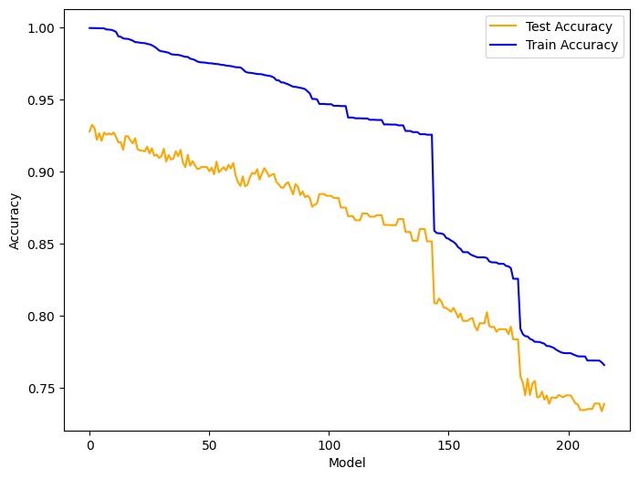

```python
plt.figure(figsize=(8, 6))

plt.plot(results_df['mean_test_accuracy'], label='Test Accuracy', color='orange')
plt.plot(results_df['mean_train_accuracy'], label='Train Accuracy', color='blue')

plt.ylabel('Accuracy')
plt.xlabel('Model')
plt.legend(loc = 'best')
plt.show()
```

The above plot shows the correlation between the accuracy of test and train models as they behave in corellation.

```python
feature_importances = best_dt.feature_importances_

feature_importance_df = pd.DataFrame({
    'Feature': X_val.columns,
    'Importance': feature_importances
})

# Sort by importance
feature_importance_df = feature_importance_df.sort_values(by='Importance', ascending=False)
feature_importance_df.reset_index(drop=True, inplace=True)

top_features = feature_importance_df.head(10)

top_features
```

|  | Feature | Importance |
| --- | --- | --- |
| 0 | 2 | 0.100194 |
| 1 | Goals - away | 0.042969 |
| 2 | Pr{Away Win} | 0.037053 |
| 3 | Assists - away | 0.034128 |
| 4 | 1 | 0.026616 |
| 5 | current_state | 0.024487 |
| 6 | Pr{Draw} | 0.022047 |
| 7 | Ball Safe - home | 0.019011 |
| 8 | Offsides - away | 0.016789 |
| 9 | Ball Safe - away | 0.016337 |

Feature Importance results for the top 10 features indicate that:

1. **2 (0.100194)**:
   - The feature labeled **"2"** represents the **odds for an away win** and has the **highest importance**. This indicates that the model heavily relies on the away win odds to predict the match outcome, more than any other feature.
2. **Goals - Away (0.042969)**:
   - The number of **goals scored by the away team** is the second most important feature. This shows that the model considers the **offensive performance** of the away team as a key predictor for the outcome.
3. **Pr{Away Win} (0.037053)**:
   - The **probability of an away win** is also an important feature, confirming that the model focuses on the likelihood of the away team winning when making predictions.
4. **Assists - Away (0.034128)**:
   - **Assists made by the away team** are another significant factor. This shows that the model values offensive contributions from the away team in predicting the match result.
5. **1 (0.026616)**:
   - The feature labeled **"1"** represents the **odds for a home win**. The model considers it important, but less so than the away win odds, suggesting that it views away win scenarios as more decisive for predicting outcomes.
6. **current_state (0.024487)**:
   - The **current state of the match** plays a moderate role in the model’s decision-making.
7. **Pr{Draw} (0.022047)**:
   - The **probability of a draw** is given some importance, indicating that the model considers this outcome but not as strongly as home or away wins.
8. **Offsides - Away (0.016789)**:
   - **Offsides committed by the away team** also play a minor role in predictions, suggesting that frequent offside calls might signal an overly aggressive or poorly timed attack strategy.
- The model heavily relies on **away win odds (2)** as the primary predictor, indicating that the **betting odds for away wins** are the most decisive factor.
- **Offensive statistics** like **goals scored** and **assists by the away team** are significant contributors.
- **Home win odds (1)** are less important than away win odds, suggesting that the model perceives away wins as more uncertain or impactful for prediction accuracy.

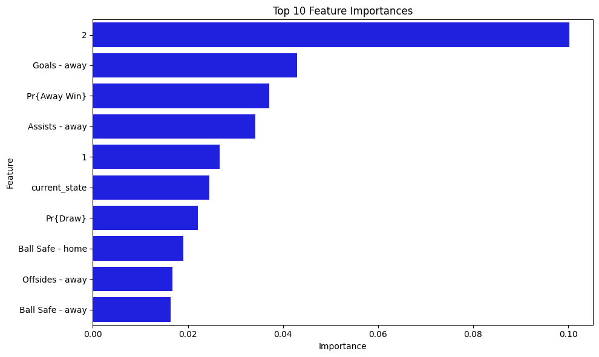

```python
plt.figure(figsize=(10, 6))
sns.barplot(
    x='Importance',
    y='Feature',
    data=top_features,
    hue=None,
    color='blue'
)

plt.title('Top 10 Feature Importances')
plt.xlabel('Importance')
plt.ylabel('Feature')
plt.tight_layout()
plt.show()
```

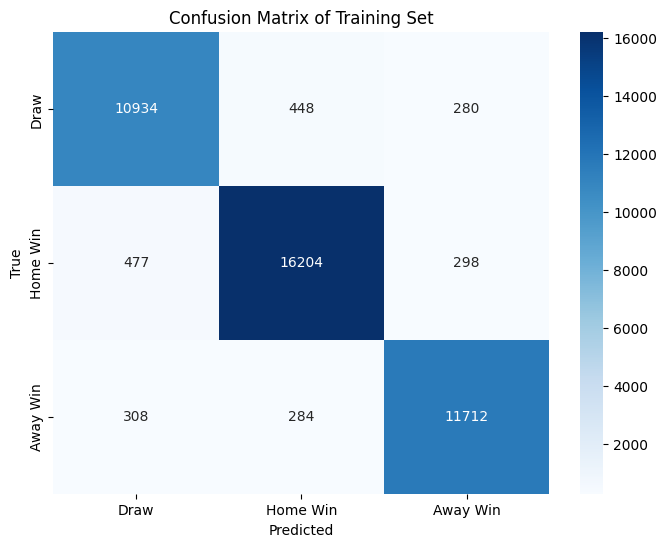

```python
cm = confusion_matrix(y_full_train, train_predictions)

plt.figure(figsize=(8, 6))
sns.heatmap(cm, annot=True, fmt="d", cmap="Blues", xticklabels=["Draw","Home Win", "Away Win"], yticklabels=["Draw","Home Win", "Away Win"])
plt.xlabel('Predicted')
plt.ylabel('True')
plt.title('Confusion Matrix of Training Set')
plt.show()
```

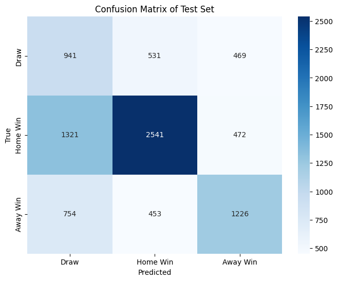

```python
cm = confusion_matrix(y_test, test_predictions)

plt.figure(figsize=(8, 6))
sns.heatmap(cm, annot=True, fmt="d", cmap="Blues", xticklabels=["Draw","Home Win", "Away Win"], yticklabels=["Draw","Home Win", "Away Win"])
plt.xlabel('Predicted')
plt.ylabel('True')
plt.title('Confusion Matrix of Test Set')
plt.show()
```

## Generating A Betting Strategy

The betting strategy revolves around the predictive power of the models. For each instance, the decision tree provides a probability for the predicted outcome. This probability indicates the model's confidence in the outcome being correct. To decide when a bet should be placed, thresholds of **0.33**, **0.5**, and **0.9** are applied for different experiments to also get insights from the selection of treshold values. Once the probability of a predicted outcome reaches the threshold for the first time, a bet is placed based on the prediction using only the information available at that moment, with no opportunity to revise the decision later.

In decision tree models, these probabilities typically take the form of **(1, 0, 0)**, meaning that the model assigns full confidence to the predicted outcome for each instance. As a result, the bet is placed at the earliest available opportunity, as the model already exceeds any of the given thresholds as soon as the first data is collected. This approach resembles a **pre-game betting strategy**, where bets are placed before the match starts, rather than a **live betting strategy** that adjusts based on in-game events.

While other models may update their probabilities dynamically and adapt to new information as it comes in, the decision tree model makes its decision at the first available instance. This is due to the model’s inherent nature of assigning **absolute confidence** to its predictions once a decision is reached, making it different from probabilistic models that offer more nuanced predictions.

```python
predict_proba_dt = best_dt.predict_proba(X_test) # Get the probabilities of the predictions

# Create a DataFrame with the probabilities, real results, predicted results, fixture_id and odds
betting_df = pd.DataFrame(predict_proba_dt, columns=[f'{i}' for i in range(predict_proba_dt.shape[1])])
betting_df["real_result"] = y_test
betting_df["predicted_result"] = test_predictions
betting_df["fixture_id"] = test_df["fixture_id"].values
betting_df["Odd_Home"] = test_df["1"].values
betting_df["Odd_Away"] = test_df["2"].values
betting_df["Odd_Draw"] = test_df["X"].values

# Iterate over the rows and bet based on the probabilities
betted_rows_dt_1 = {}

for fixture_id, match in betting_df.groupby("fixture_id"):
    for id_, row in match.iterrows():

        if row["0"] > 0.33:
            betted_rows_dt_1[fixture_id] = {"bet": "Draw", "odd": row["Odd_Draw"]}
            break
        elif row["1"] > 0.33:
            betted_rows_dt_1[fixture_id] = {"bet": "Home Win", "odd": row["Odd_Home"]}
            break
        elif row["2"] > 0.33:
            betted_rows_dt_1[fixture_id] = {"bet": "Away Win", "odd": row["Odd_Away"]}
            break

# Calculate the total return
total_return_dt_1 = 0

for fixture_id, betting_detail in betted_rows_dt_1.items():

    real_result = betting_df[betting_df["fixture_id"] == fixture_id]["real_result"].values[0]
    odd = betting_detail["odd"]
    bet = betting_detail["bet"]

    if bet == "Draw" and real_result == 0:
        total_return_dt_1 += odd
    elif bet == "Home Win" and real_result == 1:
        total_return_dt_1 += odd
    elif bet == "Away Win" and real_result == 2:
        total_return_dt_1 += odd
    else:
        continue


profit_dt1 = total_return_dt_1 - len(betted_rows_dt_1)
print(f"{total_return_dt_1:.2f} units of earn")
print(f"{profit_dt1:.2f} units of profit")
```

```
120.11 units of earn
9.11 units of profit
```

```python
predict_proba_dt = best_dt.predict_proba(X_test) # Get the probabilities of the predictions

# Create a DataFrame with the probabilities, real results, predicted results, fixture_id and odds
betting_df = pd.DataFrame(predict_proba_dt, columns=[f'{i}' for i in range(predict_proba_dt.shape[1])])
betting_df["real_result"] = y_test
betting_df["predicted_result"] = test_predictions
betting_df["fixture_id"] = test_df["fixture_id"].values
betting_df["Odd_Home"] = test_df["1"].values
betting_df["Odd_Away"] = test_df["2"].values
betting_df["Odd_Draw"] = test_df["X"].values

# Iterate over the rows and bet based on the probabilities
betted_rows_dt_2 = {}

for fixture_id, match in betting_df.groupby("fixture_id"):
    for id_, row in match.iterrows():

        if row["0"] > 0.5:
            betted_rows_dt_2[fixture_id] = {"bet": "Draw", "odd": row["Odd_Draw"]}
            break
        elif row["1"] > 0.5:
            betted_rows_dt_2[fixture_id] = {"bet": "Home Win", "odd": row["Odd_Home"]}
            break
        elif row["2"] > 0.5:
            betted_rows_dt_2[fixture_id] = {"bet": "Away Win", "odd": row["Odd_Away"]}
            break

# Calculate the total return
total_return_dt_2 = 0

for fixture_id, betting_detail in betted_rows_dt_2.items():

    real_result = betting_df[betting_df["fixture_id"] == fixture_id]["real_result"].values[0]
    odd = betting_detail["odd"]
    bet = betting_detail["bet"]

    if bet == "Draw" and real_result == 0:
        total_return_dt_2 += odd
    elif bet == "Home Win" and real_result == 1:
        total_return_dt_2 += odd
    elif bet == "Away Win" and real_result == 2:
        total_return_dt_2 += odd
    else:
        continue

profit_dt2 = total_return_dt_2 - len(betted_rows_dt_2)
print(f"{total_return_dt_2:.2f} units of earn")
print(f"{profit_dt2:.2f} units of profit")
```

```
120.11 units of earn
9.11 units of profit
```

```python
predict_proba_dt = best_dt.predict_proba(X_test) # Get the probabilities of the predictions

# Create a DataFrame with the probabilities, real results, predicted results, fixture_id and odds
betting_df = pd.DataFrame(predict_proba_dt, columns=[f'{i}' for i in range(predict_proba_dt.shape[1])])
betting_df["real_result"] = y_test
betting_df["predicted_result"] = test_predictions
betting_df["fixture_id"] = test_df["fixture_id"].values
betting_df["Odd_Home"] = test_df["1"].values
betting_df["Odd_Away"] = test_df["2"].values
betting_df["Odd_Draw"] = test_df["X"].values

# Iterate over the rows and bet based on the probabilities
betted_rows_dt_3 = {}

for fixture_id, match in betting_df.groupby("fixture_id"):
    for id_, row in match.iterrows():

        if row["0"] > 0.9:
            betted_rows_dt_3[fixture_id] = {"bet": "Draw", "odd": row["Odd_Draw"]}
            break
        elif row["1"] > 0.9:
            betted_rows_dt_3[fixture_id] = {"bet": "Home Win", "odd": row["Odd_Home"]}
            break
        elif row["2"] > 0.9:
            betted_rows_dt_3[fixture_id] = {"bet": "Away Win", "odd": row["Odd_Away"]}
            break

# Calculate the total return
total_return_dt_3 = 0

for fixture_id, betting_detail in betted_rows_dt_3.items():

    real_result = betting_df[betting_df["fixture_id"] == fixture_id]["real_result"].values[0]
    odd = betting_detail["odd"]
    bet = betting_detail["bet"]

    if bet == "Draw" and real_result == 0:
        total_return_dt_3 += odd
    elif bet == "Home Win" and real_result == 1:
        total_return_dt_3 += odd
    elif bet == "Away Win" and real_result == 2:
        total_return_dt_3 += odd
    else:
        continue

profit_dt3 = total_return_dt_3 - len(betted_rows_dt_3)
print(f"{total_return_dt_3:.2f} units of earn")
print(f"{profit_dt3:.2f} units of profit")
```

```
120.11 units of earn
9.11 units of profit
```

The consistent earn of **120.11 units across all thresholds** suggests that the decision tree model is confident in its predictions and identifies valuable betting opportunities early. Since the model reaches a probability of **1.0** for its chosen outcome in all cases, the profit result remains unaffected by the threshold values. For 111 games to place the bet it gives an earn of 120.11 with the total profit of 9.11.

### Random Forest Classification

The approach consists of **hyperparameter tuning** for a **Random Forest Classifier** using **GridSearchCV** to find the best combination of hyperparameters that maximizes model accuracy.

By setting different hyperparameter values to test in the Random Forest model, the best-performing combination is aimed to be obtained.

- **`n_estimators`**: Number of trees in the forest (50, 100, 200).
- **`max_depth`**: Maximum depth of each tree (5 or 10).
- **`min_samples_split`**: Minimum number of samples required to split a node (2 or 5).
- **`min_samples_leaf`**: Minimum number of samples required at a leaf node (1 or 5).
- **`n_jobs`**: Number of CPU cores to use (-1 means using all available cores).
- **`class_weight`**: Handles imbalanced classes by adjusting weights (`'balanced'` or `None`).

The method automatically tests every combination of the parameters. And their performance in terms of accuracy is compared. It tries to ensure the model is **evaluated reliably** using cross-validation. This process helps build a Random Forest model that is **fine-tuned for accuracy** and **generalizes well to unseen data**.

```python
# Parameter Combination for Random Forest
param_grid = {
    'n_estimators': [50 ,100, 200],
    'max_depth':  [5, 10],
    'min_samples_split': [2, 5],
    'min_samples_leaf': [1, 5],
    'n_jobs': [-1],
    'class_weight': ['balanced', None]}
```

```python
# Find the best parameters for the Random Forest model
rf = RandomForestClassifier(random_state=123)

grid_search = GridSearchCV(estimator=rf,
                           param_grid=param_grid,
                           cv=10,
                           scoring='accuracy',
                           return_train_score=True,
                           n_jobs=-1,
                           verbose=1)

grid_search.fit(X_val, y_val)
```

```
Fitting 10 folds for each of 48 candidates, totalling 480 fits
```

```
GridSearchCV(cv=10, estimator=RandomForestClassifier(random_state=123),
             n_jobs=-1,
             param_grid={'class_weight': ['balanced', None],
                         'max_depth': [5, 10], 'min_samples_leaf': [1, 5],
                         'min_samples_split': [2, 5],
                         'n_estimators': [50, 100, 200], 'n_jobs': [-1]},
             return_train_score=True, scoring='accuracy', verbose=1)
```

```python
best_rf = grid_search.best_estimator_
best_params = grid_search.best_params_

# Predict on the training set and test set using the best model
train_predictions = best_rf.predict(X_full_train)
test_predictions = best_rf.predict(X_test)

# Calculate the accuracies
train_accuracy_rf = accuracy_score(y_full_train, train_predictions)
test_accuracy_rf = accuracy_score(y_test, test_predictions)

# Print the best parameters and accuracies
print(f"Best Parameters: {best_params}")
print(f"Training Accuracy: {train_accuracy_rf:.4f}")
print(f"Test Accuracy: {test_accuracy_rf:.4f}")
```

```
Best Parameters: {'class_weight': 'balanced', 'max_depth': 10, 'min_samples_leaf': 1, 'min_samples_split': 2, 'n_estimators': 100, 'n_jobs': -1}
Training Accuracy: 0.9413
Test Accuracy: 0.6996
```

### Random Forest Results Interpretation

Best Parameters:

- **`class_weight`: 'balanced'** – The model adjusted weights to handle class imbalance.
- **`max_depth`: 10** – The trees in the forest can grow up to 10 levels deep.
- **`min_samples_leaf`: 1** – A leaf node must have at least 1 sample.
- **`min_samples_split`: 2** – A node must have at least 2 samples to split.
- **`n_estimators`: 100** – The forest has 100 decision trees.
- **`n_jobs`: -1** – The model uses all available CPU cores for parallel processing.

**Training Accuracy: 0.9413**  
The model performs **very well** on the training data, indicating it learned the patterns in the training set with about **94.1% accuracy**.

**Test Accuracy: 0.6996**  
On unseen test data, the model's accuracy drops to **69.96%**, which suggests that it **generalizes reasonably well** but isn't perfect. The drop between training and test accuracy suggests **some overfitting**, but the Random Forest is still performing much better on test data than a random guess.

### **Comparison Between Random Forest and Decision Tree**

| Model | Training Accuracy | Test Accuracy | Generalization Performance |
| --- | --- | --- | --- |
| **Random Forest** | 94.13% | 69.96% | Better generalization |
| **Decision Tree** | 94.88% | 54.07% | Poor generalization |

1. **Random Forest**:
   - **Better generalization** to test data.
   - It reduces overfitting by using an **ensemble of trees**, where multiple trees vote to make predictions.
   - The gap between training and test accuracy is more acceptable.
2. **Decision Tree**:
   - **Higher training accuracy** but **poor test accuracy**, indicating **severe overfitting**.
   - It’s likely too complex, especially with **no depth limit**, causing it to memorize the training data rather than learn patterns.
- **Random Forest is the better model here** because it generalizes better to new data.
- The Decision Tree is **too specific** to the training data, making it unreliable for real-world predictions.
- While Random Forest has a lower training accuracy than the Decision Tree, it provides a more balanced and robust performance on test data.

```python
results = grid_search.cv_results_
params = results['params']
mean_test_accuracy = results['mean_test_score']
mean_train_accuracy = results['mean_train_score']

# Create a DataFrame with the results
results_df = pd.DataFrame(params)
results_df['mean_test_accuracy'] = mean_test_accuracy
results_df['mean_train_accuracy'] = mean_train_accuracy

results_df = results_df.sort_values(by='mean_train_accuracy', ascending=False)
results_df = results_df.reset_index(drop=True)

results_df.head(10)
```

|  | class_weight | max_depth | min_samples_leaf | min_samples_split | n_estimators | n_jobs | mean_test_accuracy | mean_train_accuracy |
| --- | --- | --- | --- | --- | --- | --- | --- | --- |
| 0 | balanced | 10 | 1 | 2 | 100 | -1 | 0.935851 | 0.970703 |
| 1 | balanced | 10 | 1 | 2 | 50 | -1 | 0.933571 | 0.969880 |
| 2 | balanced | 10 | 1 | 2 | 200 | -1 | 0.934385 | 0.969825 |
| 3 | balanced | 10 | 1 | 5 | 100 | -1 | 0.933002 | 0.968722 |
| 4 | balanced | 10 | 1 | 5 | 200 | -1 | 0.933979 | 0.967826 |
| 5 | balanced | 10 | 1 | 5 | 50 | -1 | 0.932187 | 0.967537 |
| 6 | None | 10 | 1 | 2 | 200 | -1 | 0.932595 | 0.965529 |
| 7 | None | 10 | 1 | 2 | 100 | -1 | 0.931211 | 0.965257 |
| 8 | None | 10 | 1 | 2 | 50 | -1 | 0.928117 | 0.964163 |
| 9 | None | 10 | 1 | 5 | 200 | -1 | 0.929501 | 0.963249 |

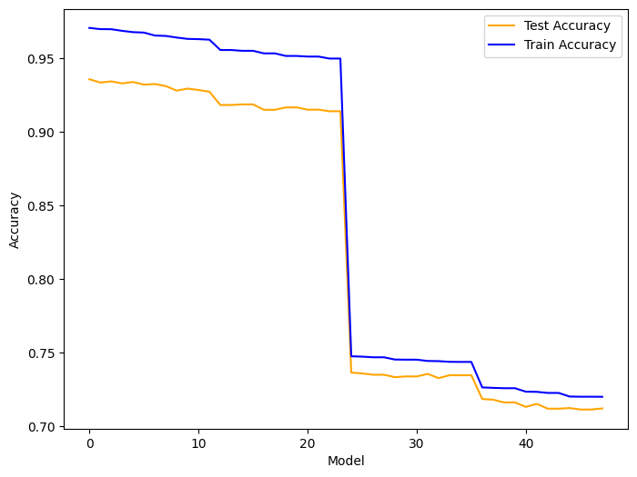

```python
plt.figure(figsize=(8, 6))

plt.plot(results_df['mean_test_accuracy'], label='Test Accuracy', color='orange')
plt.plot(results_df['mean_train_accuracy'], label='Train Accuracy', color='blue')

plt.ylabel('Accuracy')
plt.xlabel('Model')
plt.legend(loc = 'best')
plt.show()
```

The above plot shows the correlation between the accuracy of test and train models as they behave in corellation.

```python
feature_importances = best_rf.feature_importances_

feature_importance_df = pd.DataFrame({
    'Feature': X_val.columns,
    'Importance': feature_importances
})

# Sort by importance
feature_importance_df = feature_importance_df.sort_values(by='Importance', ascending=False)
feature_importance_df.reset_index(drop=True, inplace=True)

top_features = feature_importance_df.head(15)

top_features
```

|  | Feature | Importance |
| --- | --- | --- |
| 0 | Assists - home | 0.068420 |
| 1 | 1 | 0.065083 |
| 2 | 2 | 0.060728 |
| 3 | Pr{Away Win} | 0.059424 |
| 4 | Pr{Home Win} | 0.059067 |
| 5 | Assists - away | 0.050191 |
| 6 | X | 0.031391 |
| 7 | Pr{Draw} | 0.030909 |
| 8 | current_state | 0.025623 |
| 9 | Goal Difference | 0.021007 |
| 10 | Goal Attempts Difference | 0.018810 |
| 11 | Goals - away | 0.014299 |
| 12 | Ball Safe - home | 0.013707 |
| 13 | Ball Safe - away | 0.013527 |
| 14 | Goal Attempts - away | 0.013290 |

### **Feature Importance Analysis**

The most important features for predicting whether a match will end in a **Home Win (1)**, **Away Win (2)**, or **Tie (0)** are as follows:

| **Feature** | **Importance** | **Interpretation** |
| --- | --- | --- |
| **Assists - home** | 0.068420 | The number of **assists by the home team** is the most important feature. This shows that the model values the offensive contribution of the home team heavily in its predictions. |
| **1 (Home Win odds)** | 0.065083 | The **odds for a home win** are highly important in determining the outcome, reflecting the model's reliance on betting market expectations. |
| **2 (Away Win odds)** | 0.060728 | The **odds for an away win** are another critical factor, indicating that betting odds for the away team also significantly influence the prediction. |
| **Pr{Away Win}** | 0.059424 | The **probability of an away win** derived from odds is a key feature. The model heavily relies on these live-match estimations. |
| **Pr{Home Win}** | 0.059067 | Similarly, the **probability of a home win** derived from odds plays a significant role in predictions. |
| **Assists - away** | 0.050191 | The **number of assists by the away team** also impacts predictions, though to a lesser extent than home assists. |
| **X (Draw odds)** | 0.031391 | The **odds of a draw** have moderate importance, showing that the model does not entirely dismiss the tie outcome. |
| **Pr{Draw}** | 0.030909 | The **probability of a draw** is another moderately important feature, suggesting that the model considers all possible outcomes. |
| **current_state** | 0.025623 | The **current state of the match** has some influence. |
| **Goal Difference** | 0.021007 | The **difference in goals scored** between teams plays a smaller role, showing that the model considers past performance. |

### **Key Insights**

1. **Offensive contributions** like **assists by the home and away teams** are the most important features, which highlights the model’s focus on **offensive performance** to predict outcomes.
2. **Betting odds** and their derived **probabilities** (like **Pr{Home Win}** and **Pr{Away Win}**) are heavily relied upon by the model. This shows that the model uses **live-match market expectations** as key indicators.
3. **The model values home team performance more than away team performance**, as evidenced by the higher importance of home-related features like **Assists - home** and **1 (Home Win odds)**.

[figure not shown]

```python
plt.figure(figsize=(10, 6))
sns.barplot(
    x='Importance',
    y='Feature',
    data=top_features,
    hue=None,
    legend=False,
    color='blue'
)

plt.title('Top 10 Feature Importances')
plt.xlabel('Importance')
plt.ylabel('Feature')
plt.tight_layout()
plt.show()
```

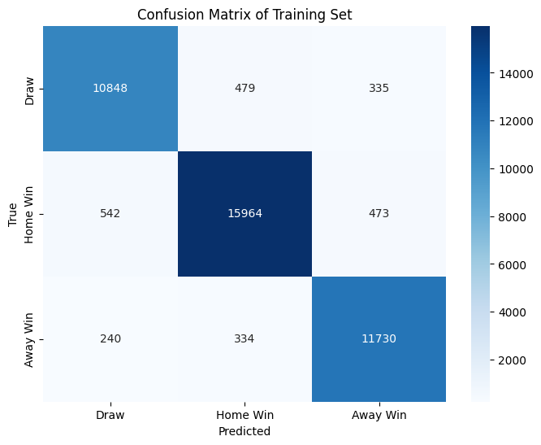

```python
cm = confusion_matrix(y_full_train, train_predictions)

plt.figure(figsize=(8, 6))
sns.heatmap(cm, annot=True, fmt="d", cmap="Blues", xticklabels=["Draw","Home Win", "Away Win"], yticklabels=["Draw","Home Win", "Away Win"])
plt.xlabel('Predicted')
plt.ylabel('True')
plt.title('Confusion Matrix of Training Set')
plt.show()
```

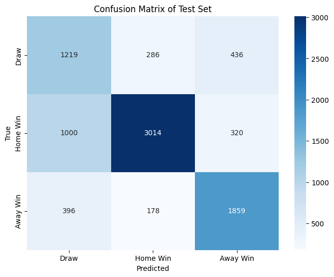

```python
cm = confusion_matrix(y_test, test_predictions)

plt.figure(figsize=(8, 6))
sns.heatmap(cm, annot=True, fmt="d", cmap="Blues", xticklabels=["Draw","Home Win", "Away Win"], yticklabels=["Draw","Home Win", "Away Win"])
plt.xlabel('Predicted')
plt.ylabel('True')
plt.title('Confusion Matrix of Test Set')
plt.show()
```

## Generating A Betting Strategy

The betting strategy is same as before. For each instance, the random forest provides a probability for the predicted outcome. This probability indicates the model's confidence in the outcome being correct. To decide when a bet should be placed, thresholds of **0.33**, **0.5**, and **0.9** are applied for different experiments to also get insights from the selection of treshold values. Once the probability of a predicted outcome reaches the threshold for the first time, a bet is placed based on the prediction using only the information available at that moment, with no opportunity to revise the decision later.

Random Forest is an ensemble of multiple decision trees, where each tree gives its own prediction for the outcome of a test sample (for example, whether it's a **Home Win**, **Away Win**, or **Tie**). These trees are trained on different subsets of data and may make different predictions. These probabilities are the **relative frequency** of each outcome among the decision trees in the forest. In other words, the model uses the idea of **democracy**: each tree gets one vote, and the final probabilities are based on how many trees vote for each outcome. (Breiman, 2001, p. 4)

Thus, by comparing these probabilities with the treshold value that is set, the aim is to find the moment that reflects a strong guess about the outcome of the game that worths to place a bet.

```python
predict_proba_rf = best_rf.predict_proba(X_test) # Get the probabilities of the predictions

# Create a DataFrame with the probabilities, real results, predicted results, fixture_id and odds
betting_df = pd.DataFrame(predict_proba_rf, columns=[f'{i}' for i in range(predict_proba_rf.shape[1])])
betting_df["real_result"] = y_test
betting_df["predicted_result"] = test_predictions
betting_df["fixture_id"] = test_df["fixture_id"].values
betting_df["Odd_Home"] = test_df["1"].values
betting_df["Odd_Away"] = test_df["2"].values
betting_df["Odd_Draw"] = test_df["X"].values

# Iterate over the rows and bet based on the probabilities
betted_rows_rf_1 = {}

for fixture_id, match in betting_df.groupby("fixture_id"):
    for id_, row in match.iterrows():

        if row["0"] > 0.33:
            betted_rows_rf_1[fixture_id] = {"bet": "Draw", "odd": row["Odd_Draw"]}
            break
        elif row["1"] > 0.33:
            betted_rows_rf_1[fixture_id] = {"bet": "Home Win", "odd": row["Odd_Home"]}
            break
        elif row["2"] > 0.33:
            betted_rows_rf_1[fixture_id] = {"bet": "Away Win", "odd": row["Odd_Away"]}
            break

# Calculate the total return
total_return_rf_1 = 0

for fixture_id, betting_detail in betted_rows_rf_1.items():

    real_result = betting_df[betting_df["fixture_id"] == fixture_id]["real_result"].values[0]
    odd = betting_detail["odd"]
    bet = betting_detail["bet"]

    if bet == "Draw" and real_result == 0:
        total_return_rf_1 += odd
    elif bet == "Home Win" and real_result == 1:
        total_return_rf_1 += odd
    elif bet == "Away Win" and real_result == 2:
        total_return_rf_1 += odd
    else:
        continue


profit_rf1 = total_return_rf_1 - len(betted_rows_rf_1)
print(f"{total_return_rf_1:.2f} units of earn")
print(f"{profit_rf1:.2f} units of profit")
```

```
152.80 units of earn
41.80 units of profit
```

```python
predict_proba_dt = best_rf.predict_proba(X_test) # Get the probabilities of the predictions

# Create a DataFrame with the probabilities, real results, predicted results, fixture_id and odds
betting_df = pd.DataFrame(predict_proba_dt, columns=[f'{i}' for i in range(predict_proba_dt.shape[1])])
betting_df["real_result"] = y_test
betting_df["predicted_result"] = test_predictions
betting_df["fixture_id"] = test_df["fixture_id"].values
betting_df["Odd_Home"] = test_df["1"].values
betting_df["Odd_Away"] = test_df["2"].values
betting_df["Odd_Draw"] = test_df["X"].values

# Iterate over the rows and bet based on the probabilities
betted_rows_rf_2 = {}

for fixture_id, match in betting_df.groupby("fixture_id"):
    for id_, row in match.iterrows():

        if row["0"] > 0.5:
            betted_rows_rf_2[fixture_id] = {"bet": "Draw", "odd": row["Odd_Draw"]}
            break
        elif row["1"] > 0.5:
            betted_rows_rf_2[fixture_id] = {"bet": "Home Win", "odd": row["Odd_Home"]}
            break
        elif row["2"] > 0.5:
            betted_rows_rf_2[fixture_id] = {"bet": "Away Win", "odd": row["Odd_Away"]}
            break

# Calculate the total return
total_return_rf_2 = 0

for fixture_id, betting_detail in betted_rows_rf_2.items():

    real_result = betting_df[betting_df["fixture_id"] == fixture_id]["real_result"].values[0]
    odd = betting_detail["odd"]
    bet = betting_detail["bet"]

    if bet == "Draw" and real_result == 0:
        total_return_rf_2 += odd
    elif bet == "Home Win" and real_result == 1:
        total_return_rf_2 += odd
    elif bet == "Away Win" and real_result == 2:
        total_return_rf_2 += odd
    else:
        continue

profit_rf2 = total_return_rf_2 - len(betted_rows_rf_2)
print(f"{total_return_rf_2:.2f} units of earn")
print(f"{profit_rf2:.2f} units of profit")
```

```
155.70 units of earn
44.70 units of profit
```

```python
predict_proba_dt = best_rf.predict_proba(X_test) # Get the probabilities of the predictions

# Create a DataFrame with the probabilities, real results, predicted results, fixture_id and odds
betting_df = pd.DataFrame(predict_proba_dt, columns=[f'{i}' for i in range(predict_proba_dt.shape[1])])
betting_df["real_result"] = y_test
betting_df["predicted_result"] = test_predictions
betting_df["fixture_id"] = test_df["fixture_id"].values
betting_df["Odd_Home"] = test_df["1"].values
betting_df["Odd_Away"] = test_df["2"].values
betting_df["Odd_Draw"] = test_df["X"].values

# Iterate over the rows and bet based on the probabilities
betted_rows_rf_3 = {}

for fixture_id, match in betting_df.groupby("fixture_id"):
    for id_, row in match.iterrows():

        if row["0"] > 0.9:
            betted_rows_rf_3[fixture_id] = {"bet": "Draw", "odd": row["Odd_Draw"]}
            break
        elif row["1"] > 0.9:
            betted_rows_rf_3[fixture_id] = {"bet": "Home Win", "odd": row["Odd_Home"]}
            break
        elif row["2"] > 0.9:
            betted_rows_rf_3[fixture_id] = {"bet": "Away Win", "odd": row["Odd_Away"]}
            break

# Calculate the total return
total_return_rf_3 = 0

for fixture_id, betting_detail in betted_rows_rf_3.items():

    real_result = betting_df[betting_df["fixture_id"] == fixture_id]["real_result"].values[0]
    odd = betting_detail["odd"]
    bet = betting_detail["bet"]

    if bet == "Draw" and real_result == 0:
        total_return_rf_3 += odd
    elif bet == "Home Win" and real_result == 1:
        total_return_rf_3 += odd
    elif bet == "Away Win" and real_result == 2:
        total_return_rf_3 += odd
    else:
        continue

profit_rf3 = total_return_rf_3 - len(betted_rows_rf_3)
print(f"{total_return_rf_3:.2f} units of earn")
print(f"{profit_rf3:.2f} units of profit")
```

```
39.71 units of earn
1.71 units of profit
```

| **Threshold** | **Earn** | **Profit** |
| --- | --- | --- |
| 0.33 | 152.80 | 41.80 |
| 0.50 | 155.70 | 44.70 |
| 0.90 | 39.71 | 1.71 |

### Gradient Boosted Decision Trees

This method **optimizes the hyperparameters** for an XGBoost model using **grid search** and evaluates its performance on training and test data.

1. **Define Hyperparameter Grid**:  
   The method begins by defining a set of hyperparameters to test, including various options for things like the number of rounds, learning rate, tree depth, and other important parameters. By testing a combination of these, the goal is to find the best set of hyperparameters for the given dataset. (Sun, 2020)
2. **Set Up Grid Search**:  
   The method uses **GridSearchCV** to systematically evaluate all possible combinations of the hyperparameters from the grid. This is done using 10-fold cross-validation, which means the dataset is split into 10 parts and each combination of hyperparameters is tested using different parts of the data for training and validation. This ensures that the model’s performance is robust and not dependent on a particular split of data.
3. **Fit the Model**:  
   The **GridSearchCV** object is then fitted to the validation data (`X_val`, `y_val`), meaning that it will train multiple models using different combinations of hyperparameters and evaluate their performance. It will keep track of which combination gives the best result (in terms of accuracy).
4. **Find the Best Model**:  
   After fitting the grid search, the method extracts the **best performing model** (best estimator) and the **best combination of hyperparameters**. These hyperparameters are the ones that led to the highest accuracy during the grid search.
5. **Make Predictions**:  
   Once the best model is identified, it is used to make predictions on both the **training** set (`X_full_train`) and the **test** set (`X_test`). These predictions are then compared with the actual outcomes to compute the model’s accuracy.
6. **Evaluate Performance**:  
   Finally, the accuracy of the model is calculated for both the training data and the test data. The model's ability to generalize is assessed based on the **test accuracy**, while the **training accuracy** gives an indication of how well the model fits the data it has seen.

```python
warnings.filterwarnings("ignore", category=UserWarning, module="xgboost") # Igrone the warnings for XGBoost

# Parameter Combination for XGBoost
param_grid = {
    'nrounds': [5, 10, 20],
    'learning_rate': [0.01, 0.1],
    'max_depth': [5, 10],
    'n_estimators': [50, 200],
    'class_weight': ['balanced'],
    'objective': ['multi:softmax'],
    'eval_metric': ['merror'],
    'num_class': [3],
    'n_jobs': [-1]}
```

```python
# Find the best parameters for the XGBoost model
xgb = XGBClassifier(random_state=123)

grid_search = GridSearchCV(
    estimator = xgb,
    param_grid = param_grid,
    scoring = 'accuracy',
    cv = 10,
    verbose = 1,
    return_train_score = True)

grid_search.fit(X_val, y_val)
```

```
Fitting 10 folds for each of 24 candidates, totalling 240 fits
```

```
GridSearchCV(cv=10,
             estimator=XGBClassifier(base_score=None, booster=None,
                                     callbacks=None, colsample_bylevel=None,
                                     colsample_bynode=None,
                                     colsample_bytree=None, device=None,
                                     early_stopping_rounds=None,
                                     enable_categorical=False, eval_metric=None,
                                     feature_types=None, gamma=None,
                                     grow_policy=None, importance_type=None,
                                     interaction_constraints=None,
                                     learning_rate=None...
                                     multi_strategy=None, n_estimators=None,
                                     n_jobs=None, num_parallel_tree=None,
                                     random_state=123, ...),
             param_grid={'class_weight': ['balanced'],
                         'eval_metric': ['merror'],
                         'learning_rate': [0.01, 0.1], 'max_depth': [5, 10],
                         'n_estimators': [50, 200], 'n_jobs': [-1],
                         'nrounds': [5, 10, 20], 'num_class': [3],
                         'objective': ['multi:softmax']},
             return_train_score=True, scoring='accuracy', verbose=1)
```

```python
best_bt = grid_search.best_estimator_
best_params = grid_search.best_params_

# Predict on the training set and test set using the best model
train_predictions = best_bt.predict(X_full_train)
test_predictions = best_bt.predict(X_test)

# Calculate the accuracies
train_accuracy_bt = accuracy_score(y_full_train, train_predictions)
test_accuracy_bt = accuracy_score(y_test, test_predictions)

# Print the best parameters and accuracies
print(f"Best Parameters: {best_params}")
print(f"Training Accuracy: {train_accuracy_bt:.4f}")
print(f"Test Accuracy: {test_accuracy_bt:.4f}")
```

```
Best Parameters: {'class_weight': 'balanced', 'eval_metric': 'merror', 'learning_rate': 0.1, 'max_depth': 10, 'n_estimators': 200, 'n_jobs': -1, 'nrounds': 5, 'num_class': 3, 'objective': 'multi:softmax'}
Training Accuracy: 0.9967
Test Accuracy: 0.7010
```

### Evaluation of XGBoost Results

#### Best Parameters:

- **Class Weight:** 'balanced' — Adjusts for any class imbalances by weighing classes inversely proportional to their frequency.
- **Learning Rate (0.1):** This is a moderate learning rate, indicating a balance between fast learning and avoiding overfitting.
- **Max Depth (10):** The model uses deeper trees (10 levels), which means it can capture more complex relationships in the data.
- **N Estimators (200):** A higher number of estimators (trees) helps to reduce overfitting and improves the model’s accuracy by averaging multiple predictions.
- **Nrounds (5):** The number of boosting rounds is relatively low, indicating limited iteration for model improvement.
- **Objective:** 'multi:softmax' — This is used for multi-class classification (3 classes).
- **Eval Metric:** 'merror' — A common metric for classification that focuses on the rate of misclassification.

#### **Accuracy Results:**

- **Training Accuracy:** 0.9967
  - This is **extremely high**, indicating that the model is fitting the training data very well. However, such a high score might also suggest some **overfitting**.
- **Test Accuracy:** 0.7010
  - The **test accuracy of 70.10%** is **decent**, showing that the model generalizes reasonably well to new, unseen data. The **gap** between the training and test accuracy (around 29%) suggests some level of **overfitting**, where the model is performing too well on the training set but slightly worse on the test set.

| **Model** | **Best Test Accuracy** | **Training Accuracy** | **Overfitting Gap (%)** |
| --- | --- | --- | --- |
| **XGBoost** | 70.10% | 99.67% | 29.57% |
| **Random Forest** | 69.96% | 94.13% | 24.17% |
| **Decision Tree** | 54.07% | 94.88% | 40.81% |

- **XGBoost** performs the best on the test set (70.10%) but has a higher overfitting gap compared to Random Forest.
- **Random Forest** shows good generalization (69.96%) with a smaller overfitting gap.
- **Decision Tree** has the **worst test accuracy** (54.07%) and a high overfitting gap, indicating poor generalization.

```python
results = grid_search.cv_results_
params = results['params']
mean_test_accuracy = results['mean_test_score']
mean_train_accuracy = results['mean_train_score']

results_df = pd.DataFrame(params)
results_df['mean_test_accuracy'] = mean_test_accuracy
results_df['mean_train_accuracy'] = mean_train_accuracy

results_df = results_df.sort_values(by='mean_train_accuracy', ascending=False)
results_df = results_df.reset_index(drop=True)

results_df.head(5)
```

|  | class_weight | eval_metric | learning_rate | max_depth | n_estimators | n_jobs | nrounds | num_class | objective | mean_test_accuracy | mean_train_accuracy |
| --- | --- | --- | --- | --- | --- | --- | --- | --- | --- | --- | --- |
| 0 | balanced | merror | 0.1 | 10 | 200 | -1 | 5 | 3 | multi:softmax | 0.992429 | 1.000000 |
| 1 | balanced | merror | 0.1 | 10 | 200 | -1 | 10 | 3 | multi:softmax | 0.992429 | 1.000000 |
| 2 | balanced | merror | 0.1 | 10 | 200 | -1 | 20 | 3 | multi:softmax | 0.992429 | 1.000000 |
| 3 | balanced | merror | 0.1 | 10 | 50 | -1 | 10 | 3 | multi:softmax | 0.985103 | 0.999964 |
| 4 | balanced | merror | 0.1 | 10 | 50 | -1 | 5 | 3 | multi:softmax | 0.985103 | 0.999964 |

```python
feature_importances = best_bt.feature_importances_

feature_importance_df = pd.DataFrame({
    'Feature': X_val.columns,
    'Importance': feature_importances
})

# Sort by importance
feature_importance_df = feature_importance_df.sort_values(by='Importance', ascending=False)
feature_importance_df.reset_index(drop=True, inplace=True)

top_features = feature_importance_df.head(15)

top_features
```

|  | Feature | Importance |
| --- | --- | --- |
| 0 | Pr{Home Win} | 0.094143 |
| 1 | 2 | 0.056403 |
| 2 | Pr{Away Win} | 0.044845 |
| 3 | Pr{Draw} | 0.036868 |
| 4 | Assists - home | 0.033302 |
| 5 | Assists - away | 0.029650 |
| 6 | Total Goals | 0.021022 |
| 7 | X | 0.017436 |
| 8 | 1 | 0.015711 |
| 9 | Penalties - away | 0.015410 |
| 10 | Total Red Cards | 0.014283 |
| 11 | Penalties - home | 0.013147 |
| 12 | Free Kicks - away | 0.012801 |
| 13 | Yellowred Cards - away | 0.012587 |
| 14 | Hit Woodwork - home | 0.012476 |

### **Feature Importance Analysis**

| **Feature** | **Importance** | **Interpretation** |
| --- | --- | --- |
| **Pr{Home Win}** | 0.094143 | The **probability of a home win** derived from odds is the most important feature, indicating that the model heavily relies on live-match expectations favoring the home team. |
| **2 (Away Win odds)** | 0.056403 | The **odds for an away win** are the second most important feature, showing that the model considers away win scenarios as crucial for predictions. |
| **Pr{Away Win}** | 0.044845 | The **probability of an away win** is another significant feature, confirming that the model values betting market probabilities. |
| **Pr{Draw}** | 0.036868 | The **probability of a draw** plays a notable role, indicating that the model does not ignore the possibility of a tie. |
| **Assists - home** | 0.033302 | The **number of assists by the home team** is important, reflecting the model’s reliance on **offensive performance** from the home team. |
| **Assists - away** | 0.029650 | The **number of assists by the away team** also impacts predictions, though it is slightly less important than home assists. |
| **Total Goals** | 0.021022 | The **total number of goals** scored in the match is moderately important, showing that goal-scoring tendencies influence the outcome. |
| **X (Draw odds)** | 0.017436 | The **odds of a draw** are less important than win probabilities, but they still play a role in the model’s decision-making. |
| **1 (Home Win odds)** | 0.015711 | The **odds for a home win** are considered, but they are less impactful compared to the derived probabilities. |
| **Penalties - away** | 0.015410 | The number of **penalties conceded by the away team** slightly influences predictions, indicating that discipline factors are considered. |
| **Total Red Cards** | 0.014283 | The **total number of red cards** in a match has a minor impact, suggesting that the model considers **disciplinary actions** but not heavily. |
| **Penalties - home** | 0.013147 | The **penalties conceded by the home team** are slightly important, indicating that the model tracks both teams' discipline. |
| **Free Kicks - away** | 0.012801 | The number of **free kicks won by the away team** has a minimal impact on predictions. |
| **Yellowred Cards - away** | 0.012587 | The number of **yellow-red cards for the away team** has minor importance, showing that the model considers discipline but not as a major factor. |
| **Hit Woodwork - home** | 0.012476 | **Home team attempts that hit the woodwork** slightly influence the model’s predictions, reflecting offensive efforts that do not result in goals. |

### **Key Insights**

1. The model **strongly prioritizes live-match win probabilities**, particularly **Pr{Home Win}**, indicating reliance on betting markets for predictions.
2. **Offensive performance** (like **assists by both teams**) plays a key role in determining match outcomes, especially for home teams.
3. **Disciplinary actions** (like **penalties and red cards**) have some influence, but they are **less important** compared to goal-related features.

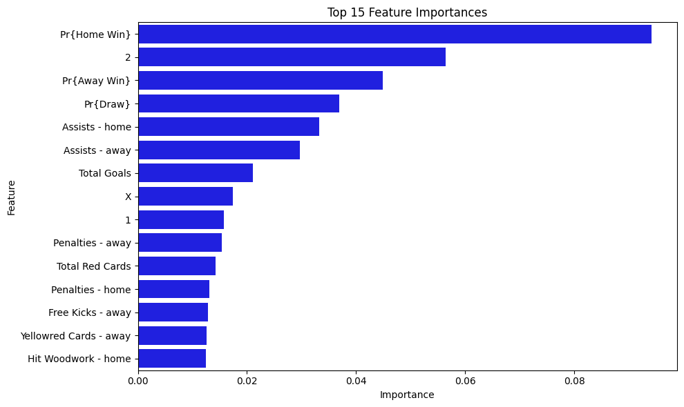

```python
plt.figure(figsize=(10, 6))
sns.barplot(
    x='Importance',
    y='Feature',
    data=top_features,
    hue=None,
    legend=False,
    color='blue'
)

plt.title('Top 15 Feature Importances')
plt.xlabel('Importance')
plt.ylabel('Feature')
plt.tight_layout()
plt.show()
```

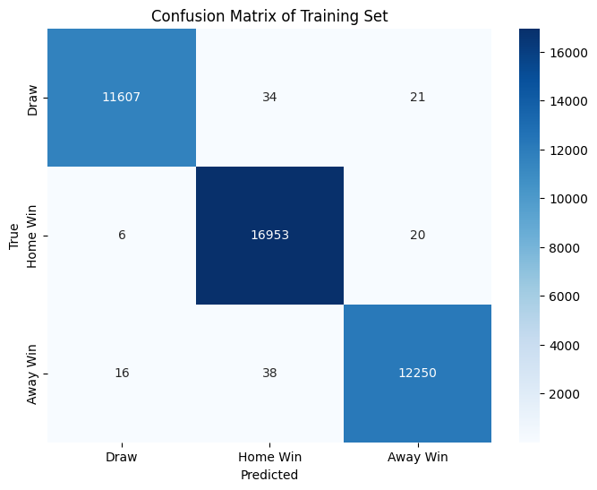

```python
cm = confusion_matrix(y_full_train, train_predictions)

plt.figure(figsize=(8, 6))
sns.heatmap(cm, annot=True, fmt="d", cmap="Blues", xticklabels=["Draw","Home Win", "Away Win"], yticklabels=["Draw","Home Win", "Away Win"])
plt.xlabel('Predicted')
plt.ylabel('True')
plt.title('Confusion Matrix of Training Set')
plt.show()
```

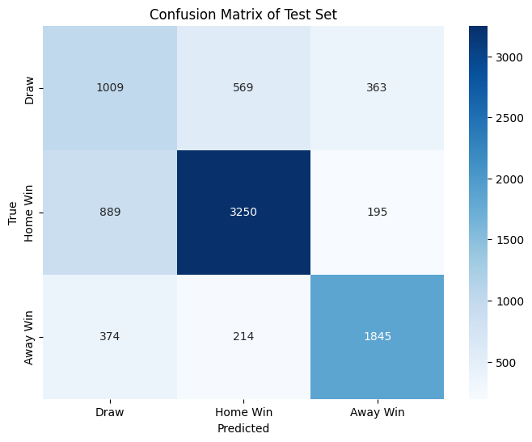

```python
cm = confusion_matrix(y_test, test_predictions)

plt.figure(figsize=(8, 6))
sns.heatmap(cm, annot=True, fmt="d", cmap="Blues", xticklabels=["Draw","Home Win", "Away Win"], yticklabels=["Draw","Home Win", "Away Win"])
plt.xlabel('Predicted')
plt.ylabel('True')
plt.title('Confusion Matrix of Test Set')
plt.show()
```

## Generating A Betting Strategy

The betting strategy is same as before. For each instance, the gradient boosted decision tree provides a probability for the predicted outcome. This probability indicates the model's confidence in the outcome being correct. To decide when a bet should be placed, thresholds of 0.33, 0.5, and 0.9 are applied for different experiments to also get insights from the selection of treshold values. Once the probability of a predicted outcome reaches the threshold for the first time, a bet is placed based on the prediction using only the information available at that moment, with no opportunity to revise the decision later.

For the XGBoost method these probabilities are calculated as such: (Duan et al., 2020)

- XGBoost builds a series of decision trees in a sequential manner. Each tree is trained to improve upon the errors of the previous tree, using a technique called **gradient boosting**.
- For each training example, the model is updated iteratively. At each stage, the decision trees predict values (scores), and these predictions are gradually adjusted based on the gradient of the loss function.
- This process results in an ensemble of trees that collectively form the final prediction.
- After training, each tree produces a **score** for each class. These scores are usually **logits** (raw values), not probabilities.
- XGBoost uses these raw output values (scores) for each class to make the final prediction. The higher the score for a given class, the more likely it is the correct class.
- To convert these raw scores into probabilities, XGBoost applies the **softmax function** to the scores for each class. The softmax function takes the raw scores for all classes and normalizes them into a probability distribution. This means that the sum of all class probabilities will always be **1**.

The softmax function is defined as:

$$ P(y = i | x) = \frac{e^{score_i}}{\sum_{j} e^{score_j}} $$

Where:

- ( P(y = i | x) ) is the probability of the example ( x ) belonging to class ( i ),
- ( score_i ) is the raw output score for class ( i ),
- The denominator sums over all possible classes, ensuring that the probabilities add up to 1.

This process ensures that XGBoost provides a **probabilistic** interpretation of its predictions, rather than just assigning a single predicted class.

Thus, by comparing these probabilities with the treshold value that is set, the aim is to find the moment that reflects a strong guess about the outcome of the game that worths to place a bet.

```python
predict_proba_xgboost = best_bt.predict_proba(X_test) # Get the probabilities of the predictions

# Create a DataFrame with the probabilities, real results, predicted results, fixture_id and odds
betting_df = pd.DataFrame(predict_proba_xgboost, columns=[f'{i}' for i in range(predict_proba_xgboost.shape[1])])
betting_df["real_result"] = y_test
betting_df["predicted_result"] = test_predictions
betting_df["fixture_id"] = test_df["fixture_id"].values
betting_df["Odd_Home"] = test_df["1"].values
betting_df["Odd_Away"] = test_df["2"].values
betting_df["Odd_Draw"] = test_df["X"].values

# Iterate over the rows and bet based on the probabilities
betted_rows_bt_1 = {}

for fixture_id, match in betting_df.groupby("fixture_id"):
    for id_, row in match.iterrows():

        if row["0"] > 0.33:
            betted_rows_bt_1[fixture_id] = {"bet": "Draw", "odd": row["Odd_Draw"]}
            break
        elif row["1"] > 0.33:
            betted_rows_bt_1[fixture_id] = {"bet": "Home Win", "odd": row["Odd_Home"]}
            break
        elif row["2"] > 0.33:
            betted_rows_bt_1[fixture_id] = {"bet": "Away Win", "odd": row["Odd_Away"]}
            break

# Calculate the total return
total_return_bt_1 = 0

for fixture_id, betting_detail in betted_rows_bt_1.items():

    real_result = betting_df[betting_df["fixture_id"] == fixture_id]["real_result"].values[0]
    odd = betting_detail["odd"]
    bet = betting_detail["bet"]

    if bet == "Draw" and real_result == 0:
        total_return_bt_1 += odd
    elif bet == "Home Win" and real_result == 1:
        total_return_bt_1 += odd
    elif bet == "Away Win" and real_result == 2:
        total_return_bt_1 += odd
    else:
        continue

profit_bt1 = total_return_bt_1 - len(betted_rows_bt_1)
print(f"{total_return_bt_1:.2f} units of earn")
print(f"{profit_bt1:.2f} units of profit")
```

```
185.77 units of earn
74.77 units of profit
```

```python
predict_proba_xgboost = best_bt.predict_proba(X_test) # Get the probabilities of the predictions

# Create a DataFrame with the probabilities, real results, predicted results, fixture_id and odds
betting_df = pd.DataFrame(predict_proba_xgboost, columns=[f'{i}' for i in range(predict_proba_xgboost.shape[1])])
betting_df["real_result"] = y_test
betting_df["predicted_result"] = test_predictions
betting_df["fixture_id"] = test_df["fixture_id"].values
betting_df["Odd_Home"] = test_df["1"].values
betting_df["Odd_Away"] = test_df["2"].values
betting_df["Odd_Draw"] = test_df["X"].values

# Iterate over the rows and bet based on the probabilities
betted_rows_bt_2 = {}

for fixture_id, match in betting_df.groupby("fixture_id"):
    for id_, row in match.iterrows():

        if row["0"] > 0.5:
            betted_rows_bt_2[fixture_id] = {"bet": "Draw", "odd": row["Odd_Draw"]}
            break
        elif row["1"] > 0.5:
            betted_rows_bt_2[fixture_id] = {"bet": "Home Win", "odd": row["Odd_Home"]}
            break
        elif row["2"] > 0.5:
            betted_rows_bt_2[fixture_id] = {"bet": "Away Win", "odd": row["Odd_Away"]}
            break

# Calculate the total return
total_return_bt_2 = 0

for fixture_id, betting_detail in betted_rows_bt_2.items():

    real_result = betting_df[betting_df["fixture_id"] == fixture_id]["real_result"].values[0]
    odd = betting_detail["odd"]
    bet = betting_detail["bet"]

    if bet == "Draw" and real_result == 0:
        total_return_bt_2 += odd
    elif bet == "Home Win" and real_result == 1:
        total_return_bt_2 += odd
    elif bet == "Away Win" and real_result == 2:
        total_return_bt_2 += odd
    else:
        continue

profit_bt2 = total_return_bt_2 - len(betted_rows_bt_2)
print(f"{total_return_bt_2:.2f} units of earn")
print(f"{profit_bt2:.2f} units of profit")
```

```
180.12 units of earn
69.12 units of profit
```

```python
predict_proba_xgboost = best_bt.predict_proba(X_test) # Get the probabilities of the predictions

# Create a DataFrame with the probabilities, real results, predicted results, fixture_id and odds
betting_df = pd.DataFrame(predict_proba_xgboost, columns=[f'{i}' for i in range(predict_proba_xgboost.shape[1])])
betting_df["real_result"] = y_test
betting_df["predicted_result"] = test_predictions
betting_df["fixture_id"] = test_df["fixture_id"].values
betting_df["Odd_Home"] = test_df["1"].values
betting_df["Odd_Away"] = test_df["2"].values
betting_df["Odd_Draw"] = test_df["X"].values

# Iterate over the rows and bet based on the probabilities
betted_rows_bt_3 = {}

for fixture_id, match in betting_df.groupby("fixture_id"):
    for id_, row in match.iterrows():

        if row["0"] > 0.9:
            betted_rows_bt_3[fixture_id] = {"bet": "Draw", "odd": row["Odd_Draw"]}
            break
        elif row["1"] > 0.9:
            betted_rows_bt_3[fixture_id] = {"bet": "Home Win", "odd": row["Odd_Home"]}
            break
        elif row["2"] > 0.9:
            betted_rows_bt_3[fixture_id] = {"bet": "Away Win", "odd": row["Odd_Away"]}
            break

# Calculate the total return
total_return_bt_3 = 0

for fixture_id, betting_detail in betted_rows_bt_3.items():

    real_result = betting_df[betting_df["fixture_id"] == fixture_id]["real_result"].values[0]
    odd = betting_detail["odd"]
    bet = betting_detail["bet"]

    if bet == "Draw" and real_result == 0:
        total_return_bt_3 += odd
    elif bet == "Home Win" and real_result == 1:
        total_return_bt_3 += odd
    elif bet == "Away Win" and real_result == 2:
        total_return_bt_3 += odd
    else:
        continue

profit_bt3 = total_return_bt_3 - len(betted_rows_bt_3)
print(f"{total_return_bt_3:.2f} units of earn")
print(f"{profit_bt3:.2f} units of profit")
```

```
145.15 units of earn
35.15 units of profit
```

| **Threshold** | **Earn** | **Profit** |
| --- | --- | --- |
| 0.33 | 185.77 | 74.77 |
| 0.50 | 180.12 | 69.12 |
| 0.90 | 145.15 | 35.15 |

## Results

```python
# Create a DataFrame with the accuracy results
accuracy_results = {
    'Method': ['Decision Tree', 'Random Forest', 'Gradient Boosted Decision Tree'],
    'Train Accuracy': [train_accuracy_dt, train_accuracy_rf, train_accuracy_bt],
    'Test Accuracy': [test_accuracy_dt, test_accuracy_rf, test_accuracy_bt]
}

accuracy_df = pd.DataFrame(accuracy_results)

accuracy_df
```

|  | Method | Train Accuracy | Test Accuracy |
| --- | --- | --- | --- |
| 0 | Decision Tree | 0.948834 | 0.540652 |
| 1 | Random Forest | 0.941312 | 0.699587 |
| 2 | Gradient Boosted Decision Tree | 0.996703 | 0.700965 |

### Model Performance Comparison

[output not shown]

1. **Decision Tree** shows **significant overfitting**, meaning it learns the training data too well but struggles to predict unseen data accurately.
2. **Random Forest** offers the **best balance** between training and test accuracy, making it the **most reliable** model of the three for generalization.
3. **Gradient Boosted Decision Tree** achieves **the highest training accuracy**, indicating it captures more complex patterns in the data. However, its **test accuracy is nearly the same** as Random Forest, suggesting it does not offer **substantial improvement** in predictive performance despite its complexity.

```python
# Create a DataFrame with the total return results
earn_results = {
    'Method': ['Decision Tree', 'Decision Tree', 'Decision Tree','Random Forest', 'Random Forest','Random Forest', 'Gradient Boosted Decision Tree', 'Gradient Boosted Decision Tree',  'Gradient Boosted Decision Tree'],
    'Treshold': [0.33, 0.5, 0.9 ,0.33, 0.5, 0.9,0.33, 0.5, 0.9],
    'Total Return': [total_return_dt_1, total_return_dt_2, total_return_dt_3, total_return_rf_1, total_return_rf_2, total_return_rf_3, total_return_bt_1, total_return_bt_2, total_return_bt_3],
    'Total Played': [len(betted_rows_dt_1), len(betted_rows_dt_2), len(betted_rows_dt_3), len(betted_rows_rf_1), len(betted_rows_rf_2), len(betted_rows_rf_3), len(betted_rows_bt_1), len(betted_rows_bt_2), len(betted_rows_bt_3)],
}

earn_df = pd.DataFrame(earn_results)
earn_df["Net Profit"] = earn_df["Total Return"] - earn_df["Total Played"]

earn_df
```

|  | Method | Treshold | Total Return | Total Played | Net Profit |
| --- | --- | --- | --- | --- | --- |
| 0 | Decision Tree | 0.33 | 120.11 | 111 | 9.11 |
| 1 | Decision Tree | 0.50 | 120.11 | 111 | 9.11 |
| 2 | Decision Tree | 0.90 | 120.11 | 111 | 9.11 |
| 3 | Random Forest | 0.33 | 152.80 | 111 | 41.80 |
| 4 | Random Forest | 0.50 | 155.70 | 111 | 44.70 |
| 5 | Random Forest | 0.90 | 39.71 | 38 | 1.71 |
| 6 | Gradient Boosted Decision Tree | 0.33 | 185.77 | 111 | 74.77 |
| 7 | Gradient Boosted Decision Tree | 0.50 | 180.12 | 111 | 69.12 |
| 8 | Gradient Boosted Decision Tree | 0.90 | 145.15 | 110 | 35.15 |

[output not shown]

1. **Gradient Boosted Decision Tree** achieves the **highest net profit** across all thresholds, especially at **0.33** and **0.50**. It’s the **best-performing model** in terms of overall return.
2. **Random Forest** is the **second-best performer**, especially at **lower thresholds**. It strikes a good balance between **return and risk**.
3. **Decision Tree** performs **poorly** and is **insensitive to threshold changes**.
4. A **threshold of 0.33 or 0.50** is generally **more profitable**, as higher thresholds reduce betting opportunities and limit profit potential.

### **Model Comparison: Accuracy vs. Profitability**

| **Model** | **Test Accuracy** | **Best Net Profit** | **Threshold for Best Profit** | **Summary** |
| --- | --- | --- | --- | --- |
| **Decision Tree** | 54.07% | 9.11 | 0.33 / 0.50 / 0.90 | **Low accuracy and low profit**. Insensitive to thresholds, indicating poor performance. |
| **Random Forest** | 69.96% | 44.70 | 0.50 | **Good accuracy and moderate profit**. Performs well with more confident bets. |
| **Gradient Boosted Decision Tree** | 70.10% | 74.77 | 0.33 | **Highest accuracy and highest profit**. Most profitable model, especially with frequent bets. |

### **Summary**

1. **Gradient Boosted Decision Tree (XGBoost)** is the **best model overall**, offering both **high accuracy** and **maximum profitability**.
2. **Random Forest** also shows **good generalization** and **decent profitability**, but slightly lags behind XGBoost.
3. **Decision Tree** performs **poorly** in both accuracy and profit, making it the **least effective model**.

In conclusion, **XGBoost** at a **0.33 threshold** offers the **most profitable and accurate betting strategy**.

## Conclusions and Future Work

This project aimed to predict match outcomes using machine learning models and evaluate their profitability in a betting scenario. Three models were employed: **Decision Tree**, **Random Forest**, and **Gradient Boosted Decision Tree (XGBoost)** usin 10-fold Cross Validation. The results showed that **Gradient Boosted Decision Tree** consistently outperformed the other models in both **accuracy** and **profitability**.

The XGBoost model achieved the **highest test accuracy (70.10%)** and produced the **highest net profit (74.77 units)** with a **threshold of 0.33**, demonstrating its strong ability to generalize and identify profitable betting opportunities. The Random Forest model also performed well, balancing accuracy and profitability, while the Decision Tree model showed significant overfitting and poor generalization to unseen data.

The analysis highlights the importance of using **ensemble methods** like Random Forest and Gradient Boosting for predictive tasks where accuracy and profitability are critical. Additionally, setting an optimal betting threshold is key to maximizing returns.

### **Future Work**

1. **Feature Engineering**
   - Incorporate more features such as **player form**, **injuries**, **weather conditions**, and **historical head-to-head records** to enhance the models' predictive power. (Wong, Li, Le, Bhangu, & Bhatia, 2025)
2. **Hyperparameter Optimization**
   - Perform more advanced hyperparameter tuning using **Bayesian optimization** or **random search** to find the optimal parameters for each model. (Sun, 2020)
3. **Model Interpretability**
   - Apply techniques like **SHAP values** to better understand how features influence predictions and identify which features are the most reliable for decision-making.
4. **Risk Management Strategies**
   - Explore **betting strategies** to mitigate risk, such as **Kelly criterion** or **bankroll management**, to improve long-term profitability.

In summary, while the models developed in this project have demonstrated strong performance, there is significant potential for improvement through enhanced features, optimized parameters, and advanced modeling techniques.

## Code

[Link to Code](https://github.com/BU-IE-582/fall-24-sudeyilmaz/blob/main/IE582_Project/code.ipynb)

## References

Štrumbelj, E., 2014. On determining probability forecasts from betting odds. International journal of forecasting, 30(4), pp.934-943.

Wong, A., Li, E., Le, H., Bhangu, G., & Bhatia, S. (2025). A predictive analytics framework for forecasting soccer match outcomes using machine learning models. Decision Analytics Journal, 14, 100537. https://doi.org/10.1016/j.dajour.2024.100537

Breiman, L. (2001). Random Forests. Machine Learning, 45(1), 5-32. https://doi.org/10.1023/A:1010933404324

Sun, L. (2020). Application and Improvement of Xgboost Algorithm Based on Multiple Parameter Optimization Strategy. In 2020 5th International Conference on Mechanical, Control and Computer Engineering (ICMCCE) (pp. 1822-1825). IEEE. https://doi.org/10.1109/ICMCCE51767.2020.00400

Duan, T., Anand, A., Ding, D.Y., Thai, K.K., Basu, S., Ng, A. & Schuler, A.. (2020). NGBoost: Natural Gradient Boosting for Probabilistic Prediction. *Proceedings of the 37th International Conference on Machine Learning*, in *Proceedings of Machine Learning Research* 119:2690-2700 Available from https://proceedings.mlr.press/v119/duan20a.html.